# Statistical Analysis

Sarah Younes

2023-11-30

```r
library(tidyverse)

tidydata =
  read.csv("data/tidydata.csv")
```

Focus on two indicators:

1. “Took Prescription Medication for Mental Health And/Or Received Counseling or Therapy”
2. “Needed Counseling or Therapy But Did Not Get It”

## Independent samples t-tests: gender

### Took prescription medication for mental health and/or received counseling or therapy

```r
gender_received =
  tidydata |>
  filter(
    indicator == "Took Prescription Medication for Mental Health And/Or Received Counseling or Therapy",
    state == "United States",
    group == "Sex",
    subgroup %in% c("Male", "Female")
  ) |>
  select(week_number, value, subgroup) |>
  pivot_wider(
    names_from = "subgroup",
    values_from = "value") |>
  janitor::clean_names()

gender_received |>
  summarise(
    t_statistic = t.test(male, female)$statistic,
    p_value = t.test(male, female)$p.value)
```

```
## # A tibble: 1 × 2
##   t_statistic  p_value
##         <dbl>    <dbl>
## 1       -39.5 3.39e-39
```

### Needed counseling or therapy but did not get it

```r
gender_needed =
  tidydata |>
  filter(
    indicator == "Needed Counseling or Therapy But Did Not Get It",
    state == "United States",
    group == "Sex",
    subgroup %in% c("Male", "Female")
  ) |>
  select(week_number, value, subgroup) |>
  pivot_wider(
    names_from = "subgroup",
    values_from = "value") |>
  janitor::clean_names()

gender_needed |>
  summarise(
    t_statistic = t.test(male, female)$statistic,
    p_value = t.test(male, female)$p.value)
```

```
## # A tibble: 1 × 2
##   t_statistic  p_value
##         <dbl>    <dbl>
## 1       -24.1 8.68e-34
```

```r
sexuality_received =
  tidydata |>
  filter(
    indicator == "Took Prescription Medication for Mental Health And/Or Received Counseling or Therapy",
    state == "United States",
    group == "Sexual orientation",
    week_number %in% c(24:33)) |>
  select(week_number, value, subgroup) |>
  pivot_wider(
    names_from = "subgroup",
    values_from = "value") |>
  janitor::clean_names()
```

```r
sexuality_needed =
  tidydata |>
  filter(
    indicator == "Needed Counseling or Therapy But Did Not Get It",
    state == "United States",
    group == "Sexual orientation",
    week_number %in% c(24:33)) |>
  select(week_number, value, subgroup) |>
  pivot_wider(
    names_from = "subgroup",
    values_from = "value") |>
  janitor::clean_names()
```

#Check normality

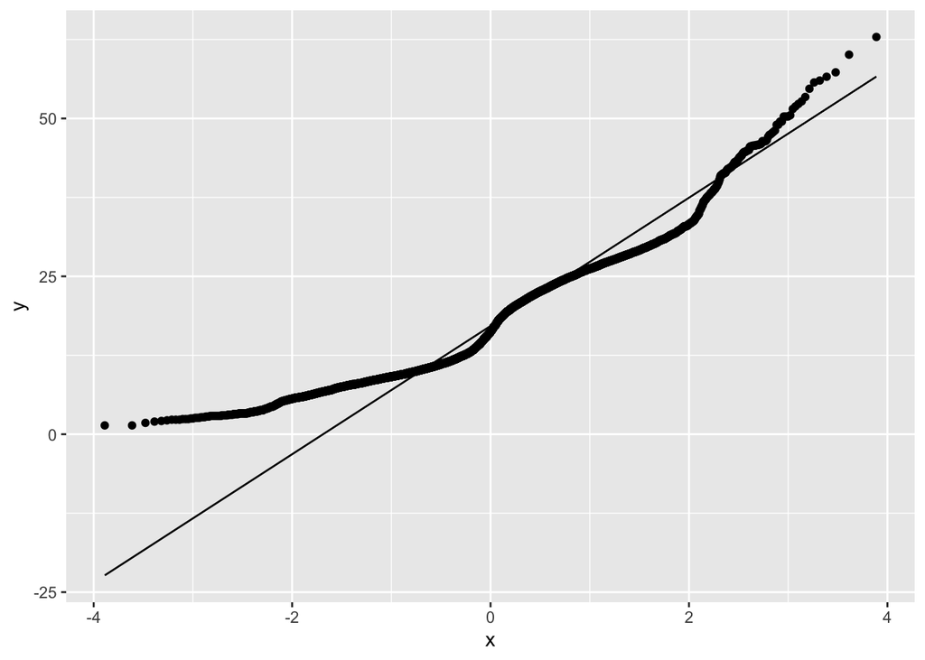

```r
ggplot(tidydata, aes(sample = value)) +
  stat_qq() +
  stat_qq_line()
```

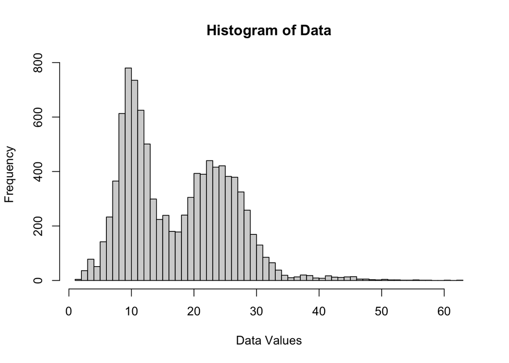

```r
 hist(tidydata$value, breaks = "FD", main = "Histogram of Data", xlab = "Data Values")
```

The plot appears to be a Q-Q (quantile-quantile) plot showing that the data deviates from the expected normal distribution, particularly in the tails, indicating the presence of outliers or a heavy-tailed distribution.